# Deloitte Productivity Cleaning Script

### Library

```r
library(tidyverse)
library(janitor)
library(readxl)
library(here)
library(fable)
library(tsibble)
library(tsibbledata)
library(lubridate)
library(slider)
library(infer)
library(scales)
library(zoo)
```

### Functions

```r
multiplesheets <- function(fname) {

  # getting info about all excel sheets
  sheets <- readxl::excel_sheets(fname)
  tibble <- lapply(sheets, function(x) readxl::read_excel(fname, sheet = x))
  data_frame <- lapply(tibble, as.data.frame)

  # assigning names to data frames
  names(data_frame) <- sheets

  # print data frame
  print(data_frame)
}

# specifying the path name
```

# Meta Data for Productivity Estimates: UK

```r
# raw - Raw Files
# pro - Productivity
# Hist - Historical

raw_sic_identify <- multiplesheets(here("data/raw_data/sic07_identifer.xlsx"))

sic_identify <- raw_sic_identify$Sheet1 %>%
  rename_with(~ gsub('Sheet2.', '', .x))

sic_identify_2 <- raw_sic_identify$Sheet2 %>%
  rename_with(~ gsub('Sheet2.', '', .x))

raw_pro_indu <- multiplesheets(here("data/raw_data/uk_Labour Productivity - Industry division_2021.xlsx"))

raw_pro_hist <- multiplesheets(here("data/raw_data/uk_labour_productivity_historical.xls"))

raw_pro_regi <- multiplesheets(here("data/raw_data/uk_Labour Productivity - Region by Industry.xls"))

raw_pro_area <- multiplesheets(here("data/raw_data/uk_labour productivity - Rural and urban areas.xls"))

raw_pro_educ <- multiplesheets(here("data/raw_data/uk_labour_productivity_education_2019.xlsx"))

raw_pro_tim  <- multiplesheets(here("data/raw_data/uk_GDP Estimates - Time Series.xlsx"))

# <- multiplesheets("data/raw_data/")

# tt <- read.delim2("data/deloitte_data_dictionary_2019.numbers", header = FALSE)

raw_world_euro <- multiplesheets(here("data/raw_data/International Labour Productivity - Europe.xls"))

raw_world_g7 <- multiplesheets(here("data/raw_data/international_labour_productivity_G7_2020.xlsx"))

raw_world_multi <- multiplesheets(here("data/raw_data/OECD_multifactor_productivity.xls"))


raw_uk_indus_region <- multiplesheets(here("data/raw_data/uk_Labour Productivity - Region by Industry_2019.xls"))


raw_oecd_gva <- read_csv("data/raw_data/OECD_gva.csv") %>%
  rename(country = "Country Name")


raw_world_prod_indus <- multiplesheets(here("data/raw_data/OECD_prod_indus.xlsx"))


raw_fac_prod <- read_csv(here("data/raw_data/OECD_GDPPHWKD_2020.csv")) %>%
  clean_names()

# Minimum Wage
raw_fac_wage_min <- multiplesheets(here("data/raw_data/OECD_real_minimum_wages_2020.xlsx"))

# Average_wage
raw_fac_wage_avg <- multiplesheets(here("data/raw_data/OECD_real_minimum_wages_2020.xlsx"))

# Unemployment_rate
raw_fac_unemployment_rate <- read_csv(here("data/raw_data/OECD_unemployment_rate_2020.csv"))

# Inflation
raw_fac_inflation <- read_csv(here("data/raw_data/OECD_inflation_2020.csv"))

# Adult Education Level
raw_fac_adult_education <- read_csv(here("data/raw_data/OECD_adult_education_2020.csv"))


raw_country_code <- multiplesheets("data/raw_data/OECD_country_code.xlsx")
country_code <- raw_country_code$Sheet1 %>%
  clean_names() %>%
  rename(country = country_name,
         code = country_code)

raw_oecd_min_wage <- multiplesheets(here("data/raw_data/OECD_real_minimum_wages_2020.xlsx"))


raw_employee_hour_worked <- read_csv((here("data/raw_data/OECD_employees_hour_worked.csv")))

raw_oecd_avg_wage <- multiplesheets(here("data/raw_data/OECD_average_wages_2020.xlsx"))
```

# Europe UK Data

```r
# Europe Output Per Hour
# Table 1: Output per hour by industry, €

clean_world_euro_oph <- raw_world_euro$`Table 1` %>%
  na.omit() %>%
  row_to_names(row_number = 1) %>%
  clean_names()

# Table 2: Labour Productivity Growth by industry 2014-16, %
clean_world_euro_growth <- raw_world_euro$`Table 2` %>%
  na.omit() %>%
  row_to_names(row_number = 1) %>%
  clean_names()
```

# Time Series

```r
clean_pro_time_year <- raw_pro_tim$data %>%
  clean_names() %>%
  filter(!grepl(' Q+[0-9]', title))

clean_pro_time_quart <- raw_pro_tim$data %>%
  clean_names() %>%
  filter(!grepl('^\\d{4}$', title))
```

```r
clean_world_multi <- as.data.frame(raw_world_multi$DP_LIVE_25012019175641197) %>%
  clean_names() %>%
  select(-flag_codes)
```

# G7, whole economy, current price (CP) in GBP

# G7 - Output per hours Productivity

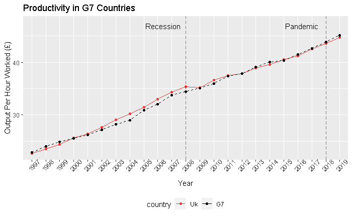

```r
# Annual output per hour worked
g7_prod <- raw_world_g7$Table_9 %>%
  na.omit() %>%
  row_to_names(row_number = 1) %>%
  clean_names() %>%
  pivot_longer(!year, names_to = "country", values_to = "productivity") %>%
  mutate(productivity = round(as.numeric(productivity), digits = 2),
         country = str_to_title(country))

g7_prod_avg <- g7_prod %>%
  group_by(year) %>%
  summarise(productivity = round(mean(productivity), digits = 2))

g7_prod %>%
  filter(country == "Uk") %>%
  ggplot()+
  aes(x = year, y = productivity, group = country, colour = country)+
  geom_point()+
  geom_line()+
  geom_line(aes(x = g7_prod_avg$year, y = g7_prod_avg$productivity, group = "G7"), linetype = 2, colour = "black")+
  geom_point(aes(x = g7_prod_avg$year, y = g7_prod_avg$productivity, group = "G7"), linetype = 2, colour = "black")+
    geom_vline(aes(xintercept = "2008"), linetype = "longdash", alpha = 0.5)+
  geom_vline(aes(xintercept = "2018"), linetype = "longdash", alpha = 0.5)+
    annotate(geom = "text",
             label = c("Recession"),
             x = c("2005"),
             y = c(47.5),
             vjust = 1,
           hjust = -.05) +
    annotate(geom = "text",
             label = c("Pandemic"),
             x = c("2015"),
             y = c(47.5),
             vjust = 1,
           hjust = -.05) +
  labs(title = "Productivity in G7 Countries")+
  xlab("Year")+
  ylab("Output Per Hour Worked (£)")+
  theme(axis.text.x = element_text(angle = 45))+
  scale_colour_manual(values = c("Uk" = "brown2", "G7" = "black"))+
  scale_linetype_manual(values = c("Uk" = "solid", "G7" = "dashed"))+
  theme(legend.position="bottom")
```

# G7 - Output Per Hour wored growth

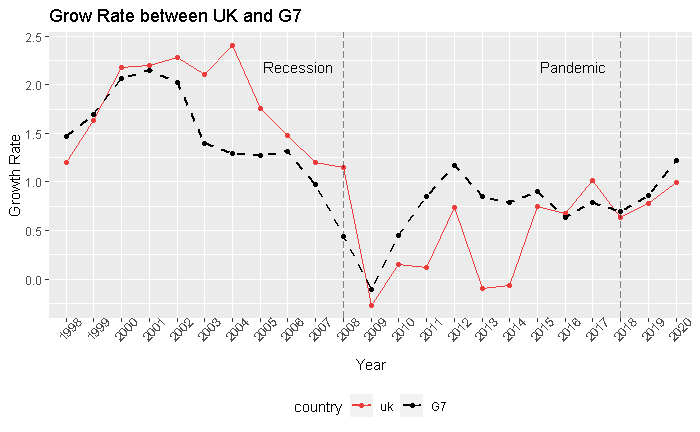

```r
g7_prod_growth <- raw_world_g7$Table_16 %>%
  na.omit() %>%
  row_to_names(row_number = 1) %>%
  clean_names()%>%
  mutate(across(c(2:8), as.numeric)) %>%
  pivot_longer(!year, names_to = "country", values_to = "growth_rate")


g7_avg_prod_growth <- g7_prod_growth%>%
  filter(country != "uk") %>%
  group_by(year) %>%
  summarise(g7_avg = mean(growth_rate))%>%
   mutate(
    moving_avg = slide_dbl(
      .x = g7_avg,
      .f = ~mean(.,na.rm = TRUE),
# 2 weeks moving average
      .before = 2
    )  )


g7_prod_growth %>%
  filter(country == "uk") %>%
   mutate(
    moving_avg = slide_dbl(
      .x = growth_rate,
      .f = ~mean(.,na.rm = TRUE),
      # 2 weeks moving average
      .before = 2
                        )) %>%
  ggplot()+
  aes(x = year, y = moving_avg, group = country, colour = country)+
  geom_point()+
  geom_line()+
  geom_line(aes(x = g7_avg_prod_growth$year, y = g7_avg_prod_growth$moving_avg, group = country, colour = "G7"), linetype = 2, size = 1)+
  geom_point(aes(x = g7_avg_prod_growth$year, y = g7_avg_prod_growth$moving_avg, group = country, colour = "G7"), linetype = 2)+
  geom_vline(aes(xintercept = "2008"), linetype = "longdash", alpha = 0.5)+
  geom_vline(aes(xintercept = "2018"), linetype = "longdash", alpha = 0.5)+
    annotate(geom = "text",
             label = c("Recession"),
             x = c("2005"),
             y = c(2.25),
             vjust = 1,
           hjust = -.05) +
    annotate(geom = "text",
             label = c("Pandemic"),
             x = c("2015"),
             y = c(2.25),
             vjust = 1,
           hjust = -.05) +

  labs(title = "Grow Rate between UK and G7")+
  xlab("Year")+
  ylab("Growth Rate")+
  theme(axis.text.x = element_text(angle = 45))+
  scale_colour_manual(values = c("uk" = "brown2", "G7" = "black"))+
  scale_linetype_manual(values = c("uk" = "solid", "G7" = "dashed"))+
  theme(legend.position="bottom")
```

# G7 - GVD

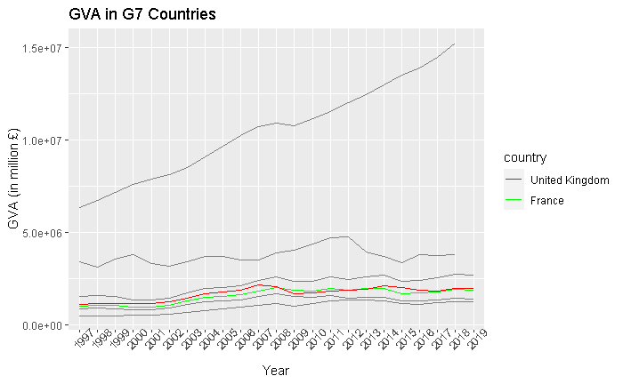

```r
oecd_gva_g7 <- raw_oecd_gva %>%
  filter(country %in% c("Canada", "France", "Germany", "Italy", "Japan", "United Kingdom", "United States")  ) %>%
  select(-c(2:41)) %>%
  pivot_longer(!country, names_to = "year", values_to = "gva") %>%
  drop_na() %>%
  # Exchange rate ~$1 = £0.77 and in millions
  mutate(gva = gva*0.77 / 1000000)


oecd_gva_g7 %>%
  ggplot()+
  aes(x = year, y = gva, group = country, colour = country)+
  geom_line()+
  labs(title = "GVA in G7 Countries")+
  xlab("Year")+
  ylab("GVA (in million £)")+
  scale_color_manual(values = c("United Kingdom" = "red", "France" = "green"))+
  theme(axis.text.x = element_text(angle = 45))
```

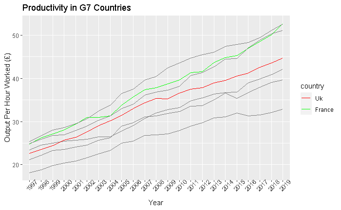

```r
g7_prod %>%
  ggplot()+
  aes(x = year, y = productivity, group = country, colour = country)+
  geom_line()+
  labs(title = "Productivity in G7 Countries")+
  xlab("Year")+
  ylab("Output Per Hour Worked (£)")+
  theme(axis.text.x = element_text(angle = 45))+
  scale_color_manual(values = c("Uk" = "red", "France" = "green"))
```

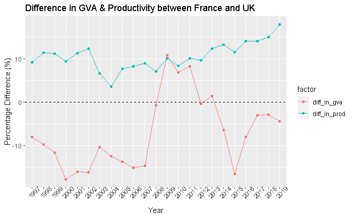

```r
uk_france_diff_prod <- g7_prod %>%
  filter(country %in% c("Uk", "France")) %>%
  pivot_wider(names_from = country, values_from = productivity) %>%
  mutate(diff_in_prod = 100*((France / Uk)-1))

uk_france_diff_gva <- oecd_gva_g7 %>%
    filter(country %in% c("United Kingdom", "France")) %>%
  pivot_wider(names_from = country, values_from = gva) %>%
  rename(Uk = 'United Kingdom') %>%
  mutate(diff_in_gva = 100*((France / Uk)-1))


uk_france_diff_prod %>%
  cbind( diff_in_gva = uk_france_diff_gva$diff_in_gva) %>%
  pivot_longer(!c(1:3), names_to = "factor", values_to = "diff_percent") %>%
  ggplot()+
    aes(x = year, y = diff_percent, group = factor, colour = factor)+
    geom_line()+
    geom_point()+
  geom_hline(yintercept = 0, linetype = "dashed")+
  labs(title = "Difference in GVA & Productivity between France and UK")+
  xlab("Year")+
  ylab("Percentage Difference (%)")+
  theme(axis.text.x = element_text(angle = 45))
```

Note: Among all the G7 countries, We will be using France as a comparison and find out factors that we can increase productivity in. France has a similar size in terms of the country and population. In the graph of difference in GVA and Productivity, you can see from the red line, GVA, that France has a lower GVA (net output) when compared to the UK, and yet the productivity gap is increasing since 2008 and onwards. In this comparison, we can reduce any confounding variables…

# UK productivity Per Industry Divison

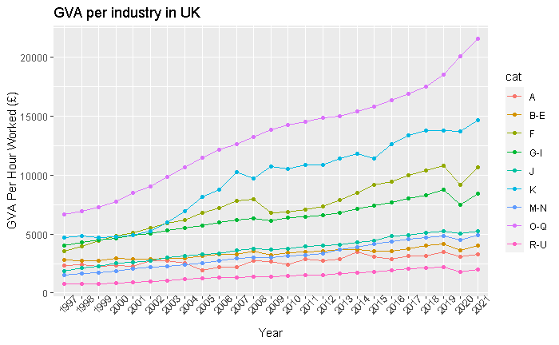

```r
# GVA Per Hour Worked in £
clean_pro_indu_gvaph <- raw_pro_indu$`GVA CP` %>%
  # Remove redundant columns
  slice(-c(1,2,3,5)) %>%
  row_to_names(row_number = 1) %>%
  rename(year = "SIC07:") %>%
  pivot_longer(!year, names_to = "sic07", values_to = "oph") %>%
  mutate(oph = round(as.numeric(oph), digits = 2)) %>%
  left_join(sic_identify, by = "sic07") %>%
  select(-c("sic07", "description")) %>%
  relocate(cat, .before = "oph") %>%
  separate(year, c("year", "quarter"), " ") %>%
  group_by(year, cat) %>%
  summarise(oph = round(mean(oph), digits = 2)) %>%
  mutate(show_we = case_when(
                    cat == "WE" ~ TRUE,
                    TRUE ~ FALSE))
clean_pro_indu_gvaph_rate <- clean_pro_indu_gvaph %>%
    ungroup() %>%
    group_by(cat) %>%
  mutate(rate = (oph - lag(oph))/lag(oph))


clean_pro_indu_gvaph %>%
  filter(cat != "L" & cat != "WE") %>%
  ggplot()+
  geom_line(aes(x = year, y  = oph, group = cat, colour = cat))+
  geom_point(aes(x = year, y  = oph, group = cat, colour = cat))+
  labs(title = "GVA per industry in UK")+
  xlab("Year")+
  ylab("GVA Per Hour Worked (£)")+
  theme(axis.text.x = element_text(angle = 45))+
  scale_linetype_manual(values = c("TRUE" = "dashed", "FALSE" = "solid"))+
  guides(linetype = FALSE)
```

A Agriculture, forestry and fishing B-E Engineering Industry F Construction Industry G-I Wholesale and retail trade, transport, accommodation and food service activities J Information and communication K Financial and insurance activities L Real Estate M-N Professional, scientific and technical activities; administrative and support service activities O-Q Public administration, defense, education, human health and social work activities R-U Arts, entertainment and recreation; other service activities

# Minimum and Average Wage

```r
oecd_min_wage <- raw_oecd_min_wage$`OECD.Stat export` %>%
  row_to_names(row_number = 1) %>%
  filter(Country %in% c("France", "United Kingdom")) %>%
  pivot_longer(!1, names_to = "year", values_to = "min_wage") %>%
  clean_names() %>%
  mutate(min_wage = round(as.numeric(min_wage), digits = 2))




oecd_avg_wage <- raw_oecd_avg_wage$`OECD.Stat export` %>%
  row_to_names(row_number = 1) %>%
  filter(Unit %in% "US Dollar, 2020", Country %in% c("France", "United Kingdom")) %>%
  select(-Unit) %>%
  pivot_longer(!1, names_to = "year", values_to = "avg_wage") %>%
  clean_names()%>%
  mutate(avg_wage = round(as.numeric(avg_wage), digits = 2))

oecd_wage <- oecd_min_wage %>%
  left_join(oecd_avg_wage, by = c("year", "country"))
```

# UK Indsutry by Region

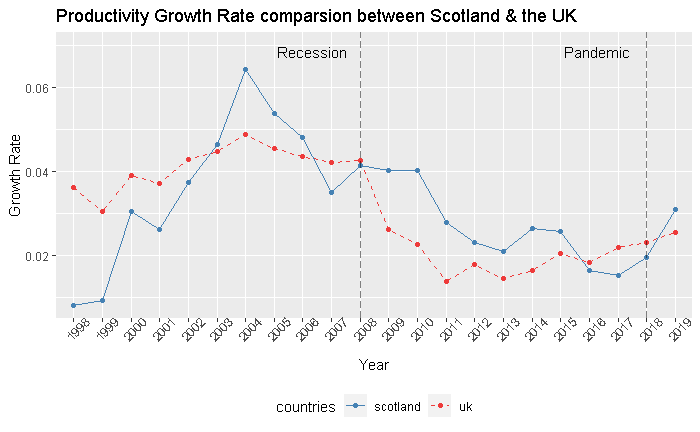

```r
uk_indus_region <- raw_uk_indus_region$`OpH (value)` %>%
  slice(-c(1:4))

uk_indus_region[2,1] <- "year"

uk_indus_region_head <- uk_indus_region[1:2,] %>%
  summarise_all(str_c, collapse=', ') %>%
  rbind(uk_indus_region) %>%
  row_to_names(row_number = 1, remove_row = FALSE)

uk_indus_region <- uk_indus_region_head[4:nrow(uk_indus_region_head),] %>%
  pivot_longer(!'Region, year', names_to = "country", values_to = "oph") %>%
  separate(country, c("region", "industry"), ", ") %>%
  separate(industry, c("sic", "industry"), ": ") %>%
  mutate(oph = round(as.numeric(oph), digits = 2)) %>%
  rename("year" = 'Region, year') %>%
  mutate(is_scot = if_else(region == "Scotland", "scotland", "other_uk_regions"),
         countries = case_when(
                  region == "Scotland" ~ "scotland",
                  region == "Wales" ~ "wales",
                  region == "Northern Ireland" ~ "northern_ireland",
                  region == "UK" ~ "uk",
                  TRUE ~ "england"))
us_indus_scot <- uk_indus_region %>%
  filter(region != "UK") %>%
  group_by(year, is_scot, sic) %>%
  summarise(avg_oph = mean(oph))
# Compare Scotland with other regions in UK for "ALL INDUSTRIES"
us_indus_scot_all <- uk_indus_region %>%
  filter(sic %in% "All Industries") %>%
  group_by(year, countries) %>%
  summarise(avg_oph = mean(oph)) %>%
  ungroup() %>%
  group_by(countries) %>%
  arrange(countries, year) %>%
  mutate(rate = (avg_oph - lag(avg_oph))/lag(avg_oph)) %>%
  ungroup() %>%
  mutate(
    moving_avg_rate = slide_dbl(
      .x = rate,
      .f = ~mean(.,na.rm = TRUE),
      # 2 weeks moving average
      .before = 2
                        ))
us_indus_scot_all %>%
  filter(countries %in%  c("scotland", "uk")) %>%
  ggplot()+
  aes(x = year, y = moving_avg_rate, group = countries, colour = countries, linetype = countries)+
  geom_line()+
  geom_point()+
  # geom_line(aes(x = year, y = rate, group = countries, colour = countries))+
  theme(axis.text.x = element_text(angle = 45))+
    geom_vline(aes(xintercept = "2008"), linetype = "longdash", alpha = 0.5)+
  geom_vline(aes(xintercept = "2018"), linetype = "longdash", alpha = 0.5)+
    annotate(geom = "text",
             label = c("Recession"),
             x = c("2005"),
             y = c(0.07),
             vjust = 1,
           hjust = -.05) +
    annotate(geom = "text",
             label = c("Pandemic"),
             x = c("2015"),
             y = c(0.07),
             vjust = 1,
           hjust = -.05) +
  labs(title = "Productivity Growth Rate comparsion between Scotland & the UK")+
  xlab("Year")+
  ylab("Growth Rate")+
  theme(axis.text.x = element_text(angle = 45))+
  scale_colour_manual(values = c("scotland" = "steelblue", "uk" = "brown2"))+
  scale_linetype_manual(values = c("scotland" = "solid", "uk" = "dashed"))+
  theme(legend.position="bottom")
```

[output not shown]

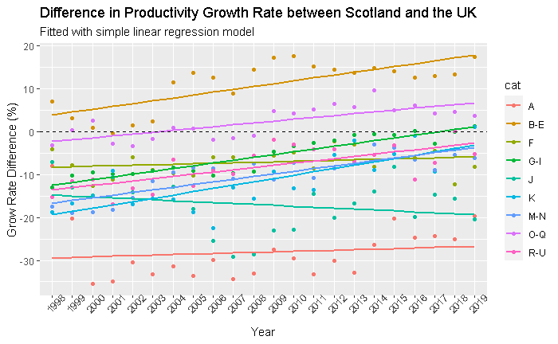

```r
uk_indus_scot_indus_cat <- uk_indus_region %>%
filter(countries %in% c("uk", "scotland") & sic != "All Industries") %>%
  mutate(sic = substr(sic,1,1)) %>%
  left_join(sic_identify_2, by = c("sic" = "sic_cat")) %>%
  select(-c("region", "sic", "is_scot")) %>%
  group_by(year, countries, cat) %>%
  summarise(avg_oph = mean(oph)) %>%
  pivot_wider(names_from = countries, values_from = avg_oph) %>%
  mutate(diff_in_oph_percent = 100*((scotland / uk)-1))
# uk_indus_scot_indus_cat %>%
  # filter(cat != c("L", "O-Q", "R-U")) %>% # CHECK
  # ggplot()+
  # aes(x = year, y = diff_in_oph_percent, group = cat, colour = cat)+
  # geom_line()+
  # geom_point()+
  # geom_hline(yintercept = 0, linetype = "dashed")+
  # labs(title = "Difference in Productivity Growth Rate",
  #      subtitle = "Comparsion between Scotland & the UK")+
  # xlab("Year")+
  # ylab("Output Per Hour Worked (£)")+
  # theme(axis.text.x = element_text(angle = 45))

uk_indus_scot_indus_cat %>%
    filter(cat != c("L", "O-Q", "R-U")) %>%
  ggplot()+
  aes(x = year, y = diff_in_oph_percent, group = cat, colour = cat)+
  geom_point()+
  geom_smooth(method = 'lm', se = FALSE)+
  geom_hline(yintercept = 0, linetype = "dashed")+
  labs(title = "Difference in Productivity Growth Rate between Scotland and the UK",
       subtitle = "Fitted with simple linear regression model")+
  xlab("Year")+
  ylab("Grow Rate Difference (%)")+
  theme(axis.text.x = element_text(angle = 45))+
  scale_y_continuous(breaks = seq(-40,40,10))
```

[output not shown]

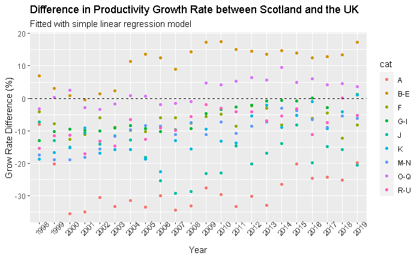

```r
uk_indus_scot_indus_cat %>%
    filter(cat != c("L", "O-Q", "R-U")) %>%
  ggplot()+
  aes(x = year, y = diff_in_oph_percent, group = cat, colour = cat)+
  geom_point()+
  # geom_smooth(method = 'lm', se = FALSE)+
  geom_hline(yintercept = 0, linetype = "dashed")+
  labs(title = "Difference in Productivity Growth Rate between Scotland and the UK",
       subtitle = "Fitted with simple linear regression model")+
  xlab("Year")+
  ylab("Grow Rate Difference (%)")+
  theme(axis.text.x = element_text(angle = 45))+
  scale_y_continuous(breaks = seq(-40,40,10))
```

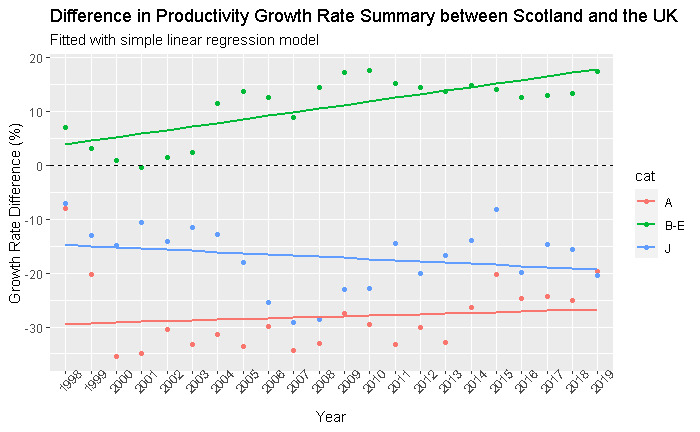

```r
uk_indus_scot_indus_cat %>%
  filter(cat %in% c("B-E", "J", "A")) %>%
  ggplot()+
  aes(x = year, y = diff_in_oph_percent, group = cat, colour = cat)+
  geom_point()+
  geom_smooth(method = 'lm', se = FALSE)+
  geom_hline(yintercept = 0, linetype = "dashed")+
  labs(title = "Difference in Productivity Growth Rate Summary between Scotland and the UK",
       subtitle = "Fitted with simple linear regression model")+
  xlab("Year")+
  ylab("Growth Rate Difference (%)")+
  theme(axis.text.x = element_text(angle = 45))+
  scale_y_continuous(breaks = seq(-40,40,10))
```

In terms of productivity

The best Scottish industry is B-E (Engineering Industry without construction)

```r
model1 <- lm(diff_in_oph_percent ~ cat, data = uk_indus_scot_indus_cat)
intercept_coef <- (model1[["coefficients"]][1])

uk_indus_coef <- as.data.frame(model1[["coefficients"]]) %>%
  rename("coefficient" = c(1)) %>%
  rownames_to_column(var = "sic_cat") %>%
  mutate(coefficient = coefficient,
          gradient = round(if_else(coefficient == intercept_coef, intercept_coef, coefficient + intercept_coef), digits = 2))
uk_indus_coef[1,1] <- "catA"


summary(model1)
```

```
Call:
lm(formula = diff_in_oph_percent ~ cat, data = uk_indus_scot_indus_cat)

Residuals:
     Min       1Q   Median       3Q      Max
-14.2056  -3.9829   0.9663   3.6354  20.1359

Coefficients:
            Estimate Std. Error t value Pr(>|t|)
(Intercept)  -28.106      1.233 -22.803  < 2e-16 ***
catB-E        38.918      1.743  22.327  < 2e-16 ***
catF          20.972      1.743  12.031  < 2e-16 ***
catG-I        22.433      1.743  12.870  < 2e-16 ***
catJ          11.029      1.743   6.327 1.48e-09 ***
catK          16.782      1.743   9.628  < 2e-16 ***
catL          32.291      1.743  18.525  < 2e-16 ***
catM-N        17.893      1.743  10.265  < 2e-16 ***
catO-Q        30.302      1.743  17.384  < 2e-16 ***
catR-U        19.969      1.743  11.456  < 2e-16 ***
---
Signif. codes:  0 ‘***’ 0.001 ‘**’ 0.01 ‘*’ 0.05 ‘.’ 0.1 ‘ ’ 1

Residual standard error: 5.781 on 210 degrees of freedom
Multiple R-squared:  0.7761,    Adjusted R-squared:  0.7665
F-statistic: 80.89 on 9 and 210 DF,  p-value: < 2.2e-16
```

```r
uk_indus_coef %>%
  arrange(desc(gradient))
```

| sic_cat | coefficient | gradient |
| --- | --- | --- |
| catB-E | 38.91840 | 10.81 |
| catL | 32.29145 | 4.19 |
| catO-Q | 30.30218 | 2.20 |
| catG-I | 22.43344 | -5.67 |
| catF | 20.97162 | -7.13 |
| catR-U | 19.96853 | -8.14 |
| catM-N | 17.89277 | -10.21 |
| catK | 16.78212 | -11.32 |
| catJ | 11.02923 | -17.08 |
| catA | -28.10597 | -28.11 |

# UK Industry by World Standard

```r
word_indus_fun = function(name, df) {
  df <- as.data.frame(df) %>%
        mutate(across(everything(), na_if, "..")) %>%
        rename("country" = 'Country') %>%
        pivot_longer(!country, names_to = "year", values_to = "rate_percent") %>%
        mutate(cat = name)

  print(df)
}

world_prod_indus_a   <- word_indus_fun("a", raw_world_prod_indus$a)
```

| country | year | rate_percent | cat |
| --- | --- | --- | --- |
| Australia | 1995 | 12.608931999999999 | a |
| Australia | 1996 | 8.3300870000000007 | a |
| Australia | 1997 | -2.046564 | a |
| Australia | 1998 | 6.430987 | a |
| Australia | 1999 | 6.545712 | a |
| Australia | 2000 | 5.4705110000000001 | a |
| Australia | 2001 | 2.6241720000000002 | a |
| Australia | 2002 | -11.274106 | a |
| Australia | 2003 | 32.492052000000001 | a |
| Australia | 2004 | 5.3894859999999998 | a |

[output cut: 952 more lines]

```r
world_prod_indus_b_e <- word_indus_fun("b_e", raw_world_prod_indus$b_e)
```

| country | year | rate_percent | cat |
| --- | --- | --- | --- |
| Australia | 1995 | 4.7174860000000001 | b_e |
| Australia | 1996 | 9.2499999999999999E-2 | b_e |
| Australia | 1997 | 6.612819 | b_e |
| Australia | 1998 | 3.4164319999999999 | b_e |
| Australia | 1999 | -3.5439690000000001 | b_e |
| Australia | 2000 | 7.5977540000000001 | b_e |
| Australia | 2001 | 1.9265600000000001 | b_e |
| Australia | 2002 | 1.292907 | b_e |
| Australia | 2003 | -1.064554 | b_e |
| Australia | 2004 | 2.1087479999999998 | b_e |

[output cut: 952 more lines]

```r
world_prod_indus_f   <- word_indus_fun("f", raw_world_prod_indus$f)
```

| country | year | rate_percent | cat |
| --- | --- | --- | --- |
| Australia | 1995 | 2.9394420000000001 | f |
| Australia | 1996 | 6.3921080000000003 | f |
| Australia | 1997 | 3.3079879999999999 | f |
| Australia | 1998 | 5.0541390000000002 | f |
| Australia | 1999 | -2.0252349999999999 | f |
| Australia | 2000 | -8.9328749999999992 | f |
| Australia | 2001 | 4.4854520000000004 | f |
| Australia | 2002 | 14.331713000000001 | f |
| Australia | 2003 | -2.1488610000000001 | f |
| Australia | 2004 | -1.169006 | f |

[output cut: 952 more lines]

```r
world_prod_indus_g_i <- word_indus_fun("g_i", raw_world_prod_indus$g_i)
```

| country | year | rate_percent | cat |
| --- | --- | --- | --- |
| Australia | 1995 | 3.1990249999999998 | g_i |
| Australia | 1996 | 5.6044600000000004 | g_i |
| Australia | 1997 | 1.9943550000000001 | g_i |
| Australia | 1998 | 2.7304810000000002 | g_i |
| Australia | 1999 | 5.5910489999999999 | g_i |
| Australia | 2000 | 0.52568800000000004 | g_i |
| Australia | 2001 | 1.569679 | g_i |
| Australia | 2002 | 0.270708 | g_i |
| Australia | 2003 | 6.6328810000000002 | g_i |
| Australia | 2004 | -0.67921299999999996 | g_i |

[output cut: 952 more lines]

```r
world_prod_indus_j   <- word_indus_fun("j", raw_world_prod_indus$j)
```

| country | year | rate_percent | cat |
| --- | --- | --- | --- |
| Australia | 1995 | -4.9980739999999999 | j |
| Australia | 1996 | 4.5120930000000001 | j |
| Australia | 1997 | 8.7610659999999996 | j |
| Australia | 1998 | 6.8833729999999997 | j |
| Australia | 1999 | -19.535990999999999 | j |
| Australia | 2000 | -3.1434160000000002 | j |
| Australia | 2001 | 12.208398000000001 | j |
| Australia | 2002 | -0.36002499999999998 | j |
| Australia | 2003 | 9.6617569999999997 | j |
| Australia | 2004 | -0.16192500000000001 | j |

[output cut: 952 more lines]

```r
world_prod_indus_k   <- word_indus_fun("k", raw_world_prod_indus$k)
```

| country | year | rate_percent | cat |
| --- | --- | --- | --- |
| Australia | 1995 | 3.1763710000000001 | k |
| Australia | 1996 | 8.0151669999999999 | k |
| Australia | 1997 | 6.3412579999999998 | k |
| Australia | 1998 | 18.695197 | k |
| Australia | 1999 | -4.6888540000000001 | k |
| Australia | 2000 | -5.550389 | k |
| Australia | 2001 | 9.3631220000000006 | k |
| Australia | 2002 | 2.3248389999999999 | k |
| Australia | 2003 | 5.3027769999999999 | k |
| Australia | 2004 | -1.139812 | k |

[output cut: 952 more lines]

```r
world_prod_indus_m_n <- word_indus_fun("m_n", raw_world_prod_indus$m_n)
```

| country | year | rate_percent | cat |
| --- | --- | --- | --- |
| Australia | 1995 | -0.96068200000000004 | m_n |
| Australia | 1996 | -0.598881 | m_n |
| Australia | 1997 | 2.504651 | m_n |
| Australia | 1998 | 5.2680910000000001 | m_n |
| Australia | 1999 | 3.9655170000000002 | m_n |
| Australia | 2000 | 6.957109 | m_n |
| Australia | 2001 | 6.5504600000000002 | m_n |
| Australia | 2002 | -3.3649040000000001 | m_n |
| Australia | 2003 | 3.1060210000000001 | m_n |
| Australia | 2004 | -5.9072680000000002 | m_n |

[output cut: 952 more lines]

```r
# Row Bind everything
world_prod_indus <- world_prod_indus_a %>%
  rbind(world_prod_indus_b_e, world_prod_indus_f, world_prod_indus_g_i, world_prod_indus_j, world_prod_indus_k, world_prod_indus_m_n) %>%
  mutate(rate_percent = as.numeric(rate_percent))
```

# G7 Test

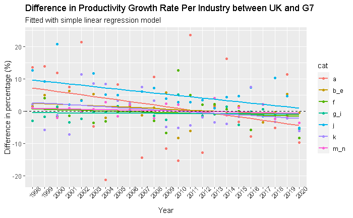

```r
uk_prod_indus <- world_prod_indus %>%
  filter(country %in% c("United Kingdom")) %>%
  select(-country)

ukg7_prod_indus <-  world_prod_indus%>%
    filter(country %in% c("United Kingdom", "France", "United States", "Italy", "Japan", "Canada", "Germany")) %>%
  group_by(year, cat) %>%
  summarise(g7_avg_growth = mean(rate_percent, na.rm= TRUE)) %>%
  filter(!year %in% c("1995", "1996", "1997")) %>%
  mutate(country = "g7") %>%
    pivot_wider(names_from = country, values_from = g7_avg_growth) %>%
    clean_names() %>%
  left_join(uk_prod_indus, key = c("cat", "country", "year")) %>%
  rename(united_kingdom = rate_percent) %>%
  mutate(diff_percent = (united_kingdom - g7))
ukg7_prod_indus %>%
  ggplot()+
  aes(year, diff_percent, group = cat, colour = cat)+
  geom_point()+
  geom_smooth(method = 'lm', se = FALSE)+
  geom_hline(yintercept = 0, linetype = "dashed")+
  labs(title = "Difference in Productivity Growth Rate Per Industry between UK and G7",
       subtitle = "Fitted with simple linear regression model")+
  xlab("Year")+
  ylab("Difference in percentage (%)")+
  theme(axis.text.x = element_text(angle = 45))
```

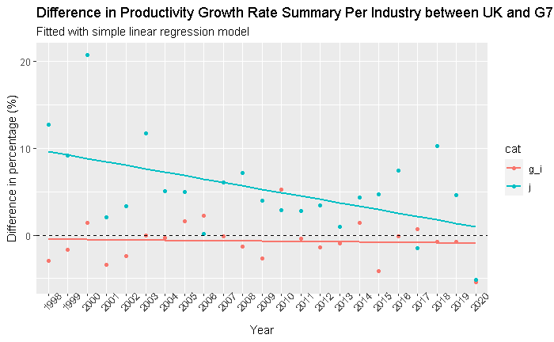

```r
ukg7_prod_indus %>%
  filter(cat %in% c("j", "g_i")) %>%
  ggplot()+
  aes(year, diff_percent, group = cat, colour = cat)+
  geom_point()+
  geom_hline(yintercept = 0, linetype = "dashed")+
  geom_smooth(method = 'lm', se = FALSE)+
  labs(title = "Difference in Productivity Growth Rate Summary Per Industry between UK and G7",
       subtitle = "Fitted with simple linear regression model")+
  xlab("Year")+
  ylab("Difference in percentage (%)")+
  theme(axis.text.x = element_text(angle = 45))
```

```r
model2 <- lm(diff_percent ~ cat, data = ukg7_prod_indus)

intercept_coef2 <- (model2[["coefficients"]][1])



ukg7_coef <- as.data.frame(model2[["coefficients"]]) %>%
  rename("coefficient" = c(1)) %>%
  rownames_to_column(var = "sic_cat") %>%
  mutate(coefficient = coefficient,
          gradient = round(if_else(coefficient == intercept_coef, intercept_coef, coefficient + intercept_coef2), digits = 2))
ukg7_coef[1,1] <- "catA"

ukg7_coef %>%
  arrange(desc(gradient))
```

| sic_cat | coefficient | gradient |
| --- | --- | --- |
| catj | 3.8640832 | 5.30 |
| catA | 1.4406359 | 2.88 |
| catb_e | -0.7259769 | 0.71 |
| catk | -1.1694671 | 0.27 |
| catm_n | -1.2989983 | 0.14 |
| catf | -1.8569876 | -0.42 |
| catg_i | -2.1451736 | -0.70 |

#Hypothesis Test

# Significant Productivity Factor

```r
fac_prod <- raw_fac_prod %>%
  select(-c("flag_codes", "frequency", "indicator", "measure")) %>%
  filter( subject %in% "TOT") %>%
  rename(year = time,
         prod_usd = value,
         code = location) %>%
  mutate(year = as.character(year),
         prod_usd = round(prod_usd, digits = 2),
        prod_rate = (prod_usd - lag(prod_usd))/lag(prod_usd))

fac_wage_min <- raw_fac_wage_min$`OECD.Stat export`  %>%
  row_to_names(row_number = 1, remove_row = TRUE) %>%
  rename(country = Country) %>%
  right_join(country_code, by = "country" ) %>%
  mutate(across(everything(), na_if, "..")) %>%
  pivot_longer(!c("country", "code"), names_to = "year", values_to = "min_wage") %>%
  mutate(min_wage = round(as.numeric(min_wage), digits = 2),
         min_wage_rate = (min_wage - lag(min_wage))/lag(min_wage)) %>%
  drop_na()

fac_wage_avg <- raw_fac_wage_avg$`OECD.Stat export`%>%
  row_to_names(row_number = 1, remove_row = TRUE) %>%
  rename(country = Country) %>%
  right_join(country_code, by = "country" ) %>%
  mutate(across(everything(), na_if, "..")) %>%
  pivot_longer(!c("country", "code"), names_to = "year", values_to = "avg_wage") %>%
  mutate(avg_wage = round(as.numeric(avg_wage), digits = 2),
         avg_wage_rate = (avg_wage - lag(avg_wage))/lag(avg_wage)) %>%
  drop_na()

fac_unemployment_rate <- raw_fac_unemployment_rate %>%
  clean_names() %>%
  filter( subject %in% "TOT") %>%
  select(-c("flag_codes", "frequency", "indicator", "measure", "subject")) %>%
  rename(year = time,
         code = location)

fac_inflation <- raw_fac_inflation %>%
  clean_names() %>%
  filter( measure %in% "AGRWTH" & subject %in% "TOT") %>%
  select(-c("flag_codes", "frequency", "indicator", "measure", "subject")) %>%
  rename(year = time,
         code = location)

# Filter with Tertiary (Uni /degree)
fac_adult_education <- raw_fac_adult_education %>%
  clean_names() %>%
  rename(code = location,
         year = time) %>%
  mutate(year = as.character(year))


fac_adult_education_try <- fac_adult_education %>%
  filter( subject %in% "TRY") %>%
  select(-subject)

# Below Upper Secondary
fac_adult_education_buppsry <- fac_adult_education %>%
  filter( subject %in% "BUPPSRY") %>%
  select(-subject)

fac_adult_education_uppsry <- fac_adult_education %>%
  filter( subject %in% "UPPSRY") %>%
  select(-subject)

fac_hrwkd <- raw_employee_hour_worked %>%
  clean_names() %>%
  rename(code = location,
         year = time) %>%
  mutate(year = as.character(year)) %>%
  select(-c("flag_codes", "frequency", "indicator", "measure", "subject"))
```

# Productivity vs Minimum Wage

# At any given point of year and country,

# does having a positive minimum wage change have a positive significant impact on productivity

# independent 1 tail test

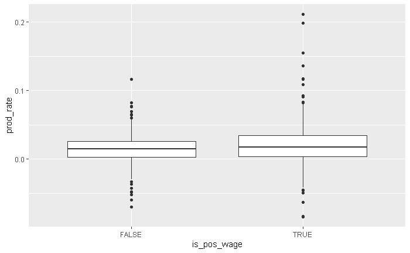

```r
test_prod_min_wage <- fac_prod %>%
  inner_join(fac_wage_min, key = c("code", "year")) %>%
  mutate(is_pos_wage = if_else(min_wage_rate >= 0, TRUE, FALSE),
         is_pos_wage = as.character(is_pos_wage))
test_prod_min_wage %>%
  ggplot()+
  aes(x = is_pos_wage, y = prod_rate)+
  geom_boxplot()
```

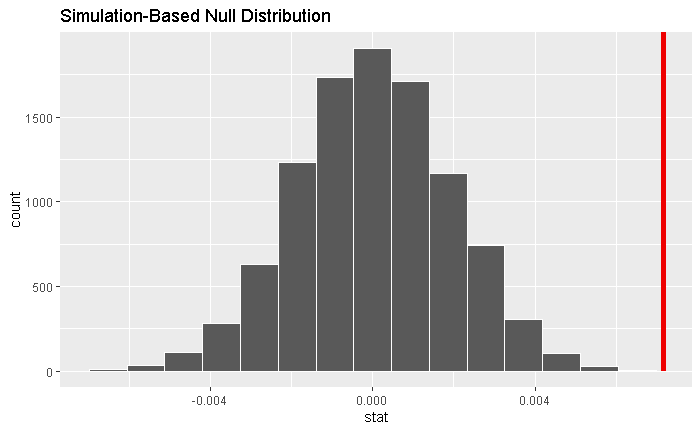

```r
null_distribution <- test_prod_min_wage %>%
  specify(prod_rate ~ is_pos_wage) %>%
  hypothesize(null = "independence") %>%
  generate(reps = 10000, type = "permute") %>%
  calculate(stat = "diff in means", order = c("TRUE", "FALSE"))

observed_stat <- test_prod_min_wage %>%
  specify(prod_rate ~ is_pos_wage) %>%
  calculate(stat = "diff in means", order = c("TRUE", "FALSE"))

null_distribution %>%
  visualise() +
  shade_p_value(obs_stat = observed_stat, direction = "right")
```

```r
p_value <- null_distribution %>%
  get_p_value(obs_stat = observed_stat, direction = "right")
p_value
```

| p_value |
| --- |
| 0 |